# excurse: Objects & Functions

Florian D. Schneider

November 16, 2015

R advanced script by Florian Schneider is licensed under a [Creative Commons Attribution 4.0 International License](http://creativecommons.org/licenses/by/4.0/).

# objects

As a very essential principle, remember that

> Everything in R is an object.

As a programming language, R handles variables. They are assigned using the `<-` arrow. Once assigned, you can call the content of an object by typing its name. This means, that anything that you can call in R by typing its name, is stored in a particular structure that is well defined by its **object class**.

## types of data

There are different types of data that R can handle. The following objects do have different specifications.

```
## [1] "double"
```

```
## [1] "double"
```

```
## [1] "logical"
```

```
## [1] "character"
```

```
## [1] "integer"
```

This becomes very important e.g. for statistical modelling, since the types prompt different kinds of analysis or plotting. The types also require different amount of space in the computer memory.[^1]

It is useful to understand that for modelling purposes and computationally intensive tasks.

| data type | usage | bits per value |
| --- | --- | --- |
| “logical” | for boolean TRUE/FALSE values, for binary data (e.g. survival) | 1 |
| “integer” | for count data, for factorial data | 3 - 32 |
| “double” | for non-integer, float numbers, percentages etc. | 32 |
| “character” | for strings of characters, written information, non-repeating words | many thousand, 8 per character |

## the object class

In general, variables are ‘objects’. There are many object classes that come with different features. Just a few examples:

```r
 f <- as.factor(c("A", "A", "B", "C", "A", "B", "B", "C", "C")); class(f)
```

```
## [1] "factor"
```

```r
 m <- matrix(sample(1:25,25), nrow = 5); class(m)
```

```
## [1] "matrix"
```

```r
 d <- data.frame(x = f, y = c(1,1,1.4,1.2,1.3,1.2,1.4,1.2,1.1)); class(d)
```

```
## [1] "data.frame"
```

```r
 l <- list(ratio = x, species = n, abundance = v, sample = f, covars = d, mat = m); class(l)
```

```
## [1] "list"
```

```r
 b <- TRUE; class(b)
```

```
## [1] "logical"
```

Thus, R can store single numerical or character values, it can store vectors of values (using `c()`), and more complex data structures like homogeneous data matrices (`matrix()`)[^2] or heterogeneous data tables (`data.frame()`). The most complex object is a list (`list()`), which can contain multiple objects of different class.

| object class | dimensions | function for creation | type of data |
| --- | --- | --- | --- |
| single value | no dimensions | e.g. `2.32`, `"a"`, `FALSE` | any type (numerical, integer, factor, binary, character) |
| vector | one dimensional | `c()` | a vector of single values of the same type |
| dataframe | two-dimensional | `data.frame()` | contains multiple vectors of same length |
| matrix | two-dimensional | `matrix()` | contains values of same type in rows and columns |
| array | n-dimensional | `array()` | contains values of same type in n-dimensions |
| list | undimensional | `list()` | contains entries of different types of objects |

Use the function `str()` to review the content and structure of an object

```r
str(d)
```

```
## 'data.frame':    9 obs. of  2 variables:
##  $ x: Factor w/ 3 levels "A","B","C": 1 1 2 3 1 2 2 3 3
##  $ y: num  1 1 1.4 1.2 1.3 1.2 1.4 1.2 1.1
```

```r
str(l)
```

```
## List of 6
##  $ ratio    : num 2.84
##  $ species  : chr "Carcinus maenas"
##  $ abundance: num [1:9] 21 32 3 42 53 43 64 23 34
##  $ sample   : Factor w/ 3 levels "A","B","C": 1 1 2 3 1 2 2 3 3
##  $ covars   :'data.frame':   9 obs. of  2 variables:
##   ..$ x: Factor w/ 3 levels "A","B","C": 1 1 2 3 1 2 2 3 3
##   ..$ y: num [1:9] 1 1 1.4 1.2 1.3 1.2 1.4 1.2 1.1
##  $ mat      : int [1:5, 1:5] 15 12 6 24 5 10 14 18 17 23 ...
```

The **main purpose of an object class is standardisation**. Functions defined to handle an object class will know where to find which information, e.g. the columns and rows of a matrix, the entries of a list. Many more object classes do exist. E.g. `"lm"` the output of a linear model:

```r
model <- lm(v ~ f); class(model)
```

```
## [1] "lm"
```

```r
summary(model)
```

```
##
## Call:
## lm(formula = v ~ f)
##
## Residuals:
##    Min     1Q Median     3Q    Max
## -33.67 -10.00   1.00   9.00  27.33
##
## Coefficients:
##             Estimate Std. Error t value Pr(>|t|)
## (Intercept)   35.333     12.091   2.922   0.0265 *
## fB             1.333     17.099   0.078   0.9404
## fC            -2.333     17.099  -0.136   0.8959
## ---
## Signif. codes:  0 '***' 0.001 '**' 0.01 '*' 0.05 '.' 0.1 ' ' 1
##
## Residual standard error: 20.94 on 6 degrees of freedom
## Multiple R-squared:  0.007793,   Adjusted R-squared:  -0.3229
## F-statistic: 0.02356 on 2 and 6 DF,  p-value: 0.9768
```

While the `summary()` function just reports the most important information in a conveniently readable form, the full content of the object can be accessed using

```r
str(model)
```

```
## List of 13
##  $ coefficients : Named num [1:3] 35.33 1.33 -2.33
##   ..- attr(*, "names")= chr [1:3] "(Intercept)" "fB" "fC"
##  $ residuals    : Named num [1:9] -14.33 -3.33 -33.67 9 17.67 ...
##   ..- attr(*, "names")= chr [1:9] "1" "2" "3" "4" ...
##  $ effects      : Named num [1:9] -105 3.54 -2.86 -3.55 28.74 ...
##   ..- attr(*, "names")= chr [1:9] "(Intercept)" "fB" "fC" "" ...
##  $ rank         : int 3
##  $ fitted.values: Named num [1:9] 35.3 35.3 36.7 33 35.3 ...
##   ..- attr(*, "names")= chr [1:9] "1" "2" "3" "4" ...
##  $ assign       : int [1:3] 0 1 1
##  $ qr           :List of 5
##   ..$ qr   : num [1:9, 1:3] -3 0.333 0.333 0.333 0.333 ...
##   .. ..- attr(*, "dimnames")=List of 2
##   .. .. ..$ : chr [1:9] "1" "2" "3" "4" ...
##   .. .. ..$ : chr [1:3] "(Intercept)" "fB" "fC"
##   .. ..- attr(*, "assign")= int [1:3] 0 1 1
##   .. ..- attr(*, "contrasts")=List of 1
##   .. .. ..$ f: chr "contr.treatment"
##   ..$ qraux: num [1:3] 1.33 1.18 1.04
##   ..$ pivot: int [1:3] 1 2 3
##   ..$ tol  : num 1e-07
##   ..$ rank : int 3
##   ..- attr(*, "class")= chr "qr"
##  $ df.residual  : int 6
##  $ contrasts    :List of 1
##   ..$ f: chr "contr.treatment"
##  $ xlevels      :List of 1
##   ..$ f: chr [1:3] "A" "B" "C"
##  $ call         : language lm(formula = v ~ f)
##  $ terms        :Classes 'terms', 'formula' length 3 v ~ f
##   .. ..- attr(*, "variables")= language list(v, f)
##   .. ..- attr(*, "factors")= int [1:2, 1] 0 1
##   .. .. ..- attr(*, "dimnames")=List of 2
##   .. .. .. ..$ : chr [1:2] "v" "f"
##   .. .. .. ..$ : chr "f"
##   .. ..- attr(*, "term.labels")= chr "f"
##   .. ..- attr(*, "order")= int 1
##   .. ..- attr(*, "intercept")= int 1
##   .. ..- attr(*, "response")= int 1
##   .. ..- attr(*, ".Environment")=<environment: R_GlobalEnv>
##   .. ..- attr(*, "predvars")= language list(v, f)
##   .. ..- attr(*, "dataClasses")= Named chr [1:2] "numeric" "factor"
##   .. .. ..- attr(*, "names")= chr [1:2] "v" "f"
##  $ model        :'data.frame':   9 obs. of  2 variables:
##   ..$ v: num [1:9] 21 32 3 42 53 43 64 23 34
##   ..$ f: Factor w/ 3 levels "A","B","C": 1 1 2 3 1 2 2 3 3
##   ..- attr(*, "terms")=Classes 'terms', 'formula' length 3 v ~ f
##   .. .. ..- attr(*, "variables")= language list(v, f)
##   .. .. ..- attr(*, "factors")= int [1:2, 1] 0 1
##   .. .. .. ..- attr(*, "dimnames")=List of 2
##   .. .. .. .. ..$ : chr [1:2] "v" "f"
##   .. .. .. .. ..$ : chr "f"
##   .. .. ..- attr(*, "term.labels")= chr "f"
##   .. .. ..- attr(*, "order")= int 1
##   .. .. ..- attr(*, "intercept")= int 1
##   .. .. ..- attr(*, "response")= int 1
##   .. .. ..- attr(*, ".Environment")=<environment: R_GlobalEnv>
##   .. .. ..- attr(*, "predvars")= language list(v, f)
##   .. .. ..- attr(*, "dataClasses")= Named chr [1:2] "numeric" "factor"
##   .. .. .. ..- attr(*, "names")= chr [1:2] "v" "f"
##  - attr(*, "class")= chr "lm"
```

Note that **most complex objects are actually lists** that were created following a particular structure. Most packages add a couple of new object classes to your R installation which might specify the consumers of a food web, the species names of a datasett, the GPS coordinates of your sample point.

In R it is easy to define own object classes:

```r
group <- structure( list(
  species = c("P.lugubris", "L.forficatus", "F.candida", "H.nitidus"),
  bodysize = c(25.3, 90.1, 0.10, 0.14),
  predator = c(TRUE, TRUE, FALSE, FALSE),
  interactions = data.frame(
    pred = c(1,1,2,2,2),
    prey = c(3,4,1,3,4)
      )
  ),
  class = "foodweb"
)
```

## access content of an object

There are two ways to access content of an object:

- access by position
- access by name

The easiest way is to use the squared brackets `[]` to address a particular position in the object. This allows you to extract a single value or range of values of a vector

```r
v[3]
```

```
## [1] 3
```

```r
v[3:6]
```

```
## [1]  3 42 53 43
```

or the columns or rows of a data frame or matrix

```r
d[,1]
d[1:3,]
m[1:3,1:3]
```

To access list entries, which applies to most complex objects that you will encounter in R, you will have to use the double squared brackets.

```r
l[[5]]
```

Note that you can sequentially combine these prompts:

```r
l[[5]][1:4,]
```

The second method to access content is ‘by name’, which works for the columns of data frames and the entries in lists. To do this, the object entries have to have names in the first place.

```r
d$x
l$species
l$covars$x
model$coefficients
```

# functions

> everything you do in R is done by a function!

Functions are the core concept of any programming language. You have a given set of functions that take a particular *input* variable and return a defined *output* variable. The base package already provides many fundamental ones for doing maths and plotting. The standard format of a function is

```r
function(x, ... )
```

where `x` is the first argument of the function, it’s *input* object[^3], and `...` can be a variable number of function arguments that specify the function’s behaviour. Examples:

```r
mean(v)       # returns the mean of the values
```

```
## [1] 35
```

```r
runif(12)     # returns random numbers from uniform distribution between 0 and 1
```

```
##  [1] 0.68946647 0.85131477 0.55969143 0.76458351 0.98309733 0.13923710
##  [7] 0.22583686 0.19982550 0.01897147 0.88957279 0.02170641 0.83876260
```

```r
sample(1:100, 12)   # samples 12 values from the vector given in the first argument
```

```
##  [1]  75  34   9  69 100  24  98   2  28  87  61  30
```

```r
rep(c("A","B","C"), each = 10)  # repeats each of the values in the vector ten times
```

```
##  [1] "A" "A" "A" "A" "A" "A" "A" "A" "A" "A" "B" "B" "B" "B" "B" "B" "B"
## [18] "B" "B" "B" "C" "C" "C" "C" "C" "C" "C" "C" "C" "C"
```

```r
cor(v, d$y, method = "pearson")   # returns pearson correlation of the two vectors
```

```
## [1] 0.2151171
```

```r
t.test(v, d$y)  # runs a t.test to compare the two vectors
```

```
##
##  Welch Two Sample t-test
##
## data:  v and d$y
## t = 5.5691, df = 8.0011, p-value = 0.0005288
## alternative hypothesis: true difference in means is not equal to 0
## 95 percent confidence interval:
##  19.80461 47.79539
## sample estimates:
## mean of x mean of y
##      35.0       1.2
```

```r
# some functions have a very different syntax
1:5           # returns a sequence of integer numbers
```

```
## [1] 1 2 3 4 5
```

```r
2 + 2 == 5    # logical operators `==` and `!=` are functions
```

```
## [1] FALSE
```

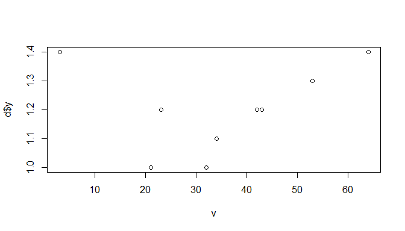

```r
# plot functions don't return an output to the console, but they open a plot window.
plot(v, d$y)
```

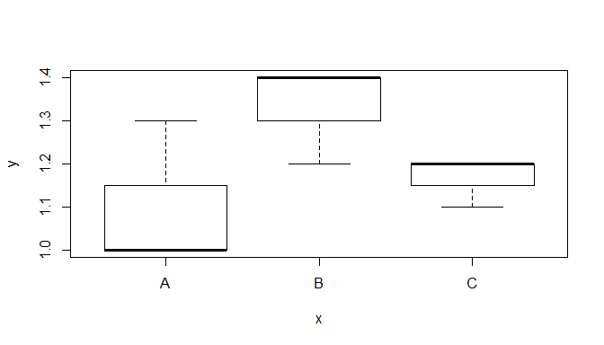

```r
plot(d)
```

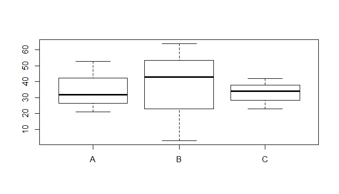

```r
plot(f, v)
```

# Wrap up:

**Objects** and **Functions** are the grammar of R. Imagine objects as nouns and functions as verbs, e.g.

- `average` `bodysizes`
- `plot` `productivity` against `temperature`
- `fit relationship` between `diversity` and `temperature`

By the way: if the function you require does not exist, just write it:

```r
add_one_to <- function(x) x+1
a <- c(0.23,0.53,0.42,0.75,0.26)

add_one_to(a)
```

```
## [1] 1.23 1.53 1.42 1.75 1.26
```

[^1]: Objects that contain data of mixed types will be coerced into the more flexible type. e.g. a vector `c("a", 1)` will be of type `"character"`.
[^2]: There is a multidimensional version of matrix, called an array (`array()`).
[^3]: some functions require a second input argument, or maybe even more